Reinaldo Augusto D. Sima - 2016025985

Múcio Henrique Mourão - 2016025861

# Lista de exercícios 3

Para realizar a análise exploratória foi escolhida a base de dados do IMDB, que está repleta de informações a respeito de filmes que foram avaliados por críticos e assinantes do site. Como informações do filme, além do básico como nome do filme e do diretor, temos também informações de receita e custos do filme, avaliações no site, país e língua do filme e dentre vários outros.

## Leitura e tratamento dos dados

Para iniciar a análise, foram utilizados os pacotes: matplotlib, seaborn, numpy e pandas, puxando os dados via uma função do pacote pandas. Depois disso, foram realizadas diversas correções no banco de dados, retirando valores nulos (e.g. N/A, Nan, Null) ou que seriam outliers (como retirando filmes que possuissem duração maior que 300 minutos e menor que 10).

```python
import matplotlib.pyplot as plt
import seaborn as sns
import numpy as np
import pandas as pd
df = pd.read_csv('movie_metadata.csv')
df.isna().sum(axis=0)

df.drop(['language'], axis=1, inplace=True)
df['gross'].fillna(0, inplace=True)
df['budget'].fillna(0, inplace=True)

df['director_name'] = np.where(df['director_name']=='N/A','', df['director_name'])
df['director_name'] = np.where(df['director_name']=='Nan','', df['director_name'])
df['director_name'] = np.where(df['director_name']=='Null','', df['director_name'])
df['movie_title'] = df['movie_title'].str.replace('Â', '')

df['duration'] = np.where(df['duration']<=10,0, df['duration'])
df['duration'] = np.where(df['duration']>300,0, df['duration'])
df['imdb_score'] = np.where(df['imdb_score']<=0,0, df['imdb_score'])
df['title_year'] = np.where(df['title_year']<1950,0, df['title_year'])
```

[output not shown]

```python
df['MLT'] = df.apply(lambda row: row['gross']/row['budget'] if row['budget']!=0 else 0, axis=1)

df['LT']= df.apply(lambda row: row['gross']-row['budget'] if row['budget']!=0 else 0, axis=1)

df['bemaval'] = df.apply(lambda row: row['imdb_score'] if row['imdb_score']>=7 else 0, axis=1)
```

Após realizar a adição dessas colunas, foi criado um novo arquivo CSV com os arquivos já limpos para ser utilizado em análises futuras. Na sequência, foi chamado novamente o arquivo para dentro de um DataFrame.

```python
df.to_csv('dadoslimpos_IMDB.csv')
df_new = pd.read_csv('dadoslimpos_IMDB.csv')
```

## Análise dos dados

Após o tratamento da base de dados, podemos começar a realizar nossa análise de dados. Para isso, escolhemos 5 análises a serem realizadas: quantidade de filmes por ano, quais são os 20 diretores e os 20 atores principais mais rentáveis, os países com mais filmes mais bem avaliados no IMDB e uma comparação entre o número de likes no Facebook com a nota no IMDB.

### Quantidade de filmes por ano

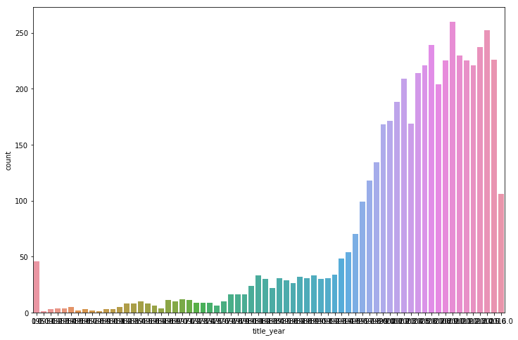

```python
plt.figure(figsize=(12,8))
sns.countplot('title_year', data = df_new)
```

O gráfico da quantidade de filmes feitos por ano demonstra como a indústria do cinema nos últimos anos está crescendo. Isso pode ser visto a partir de uma visualização simples dos dados acima. Esse boom na quantidade de filmes sendo lançados pode ser explicado pelo fato de que houve uma expansão da distribuição dos filmes por meio das mídias, assim como o desenvolvimento de novas tecnologias de filmagem e efeitos especiais e, também, o barateamento de outras tecnologias muito úteis ao cinema (e.g. filme a cor). Além disso, é importante frisar que existem quase 50 no ínicio do eixo X devido ao tratamento de dados onde zeramos os valores de filmes com anos anteriores a 1950.

### Diretores e atores mais rentáveis

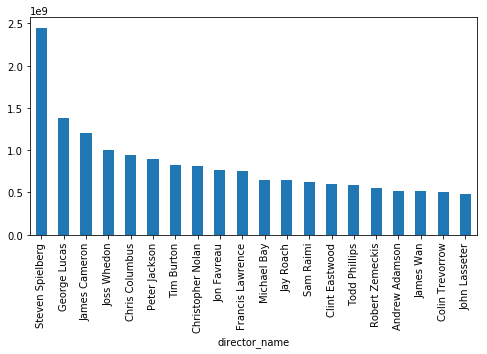

```python
diretor = df_new.groupby('director_name').sum().sort_values('LT' , ascending=False).head(20).round(3)
diretor['LT'].plot.bar(figsize=(8,4))
```

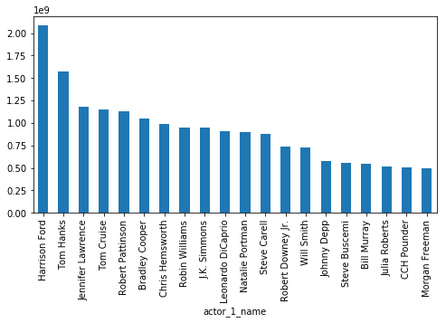

```python
atores = df_new.groupby('actor_1_name').sum().sort_values('LT' , ascending=False).head(20).round(3)
atores['LT'].plot.bar(figsize=(8,4))
```

Foram criadas duas colunas para interpretação dos dados, uma com a margem de lucro dos filmes e outra com o lucro bruto total. As duas são importantes para análises como diretores e atores mais rentáveis, uma vez que diretores pequenos com poucos filmes com um bom lucro apresentam margens absurdas mas pouco lucro bruto de fato, tornando a interpretação falaciosa sobre a rentabilidade desses diretores e/ou atores. O lucro bruto total mostra diretores com ganhos totais em seus filmes na casa dos bilhões de dólares. Poderia ser criado um algoritmo que casasse a melhor seleção de atores e diretores para tornar um filme o mais lucrativo possível.

### Países com mais filmes mais bem avaliados no IMDB

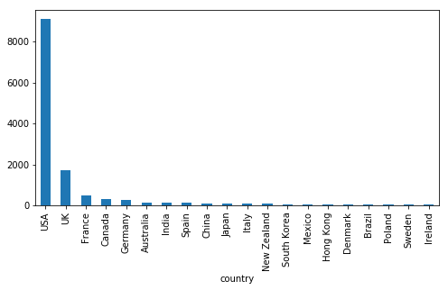

```python
ratingestrang = df.groupby('country').sum().sort_values('bemaval', ascending=False).head(20).round(3)
ratingestrang['bemaval'].plot.bar(figsize=(8,4))
```

Foi criada uma coluna chamada bemaval que seleciona apenas os filmes bem avaliados no IMDB ao tornar as notas dos filmes abaixo de 7, notas de valor 0. Dessa forma, ao agrupar por países e classificar os valores da soma notas do IMDB, os países com notas mais altas são aqueles que apresentam um maior número de filmes bem ranqueados no site.

### Relação Nota IMDB vs Likes no Facebook

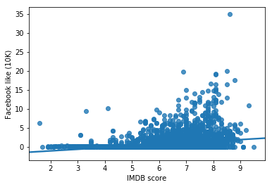

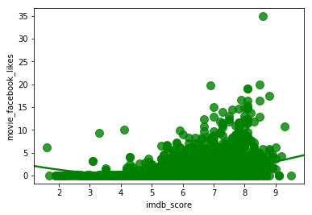

```python
df['movie_facebook_likes']=df['movie_facebook_likes'].apply(lambda row: row/10000)
X = df['budget'].values[:,np.newaxis]
y = df['movie_facebook_likes'].values
ax= sns.regplot('imdb_score', 'movie_facebook_likes',  df)

plt.xlabel('IMDB score')
plt.ylabel('Facebook like (10K)')

plt.show()
ax=sns.regplot('imdb_score', 'movie_facebook_likes',  df, ci=70, scatter_kws={"s":100}, order=2, fit_reg=True,color="g")
```

A partir do gráfico e dos dados brutos analisados na regressão, é possível perceber uma correlação positiva entre o número de likes no Facebook e a pontuação no IMDB. No entanto, percebe-se um erro do modelo muito grande para algumas variáveis. Acreditamos ser possível elaborar um modelo de previsão que consiga, a partir da nota no IMDB, prever o número de likes e a repercussão no na rede social. O sentido contrário também é possível, criando um algoritmo de cálculo para a nota do filme baseado em seu sucesso no Facebook.